# 데이터 과학자가 바라본 제7회 지방선거

유튜브 채널 - 경기지사

# 1. 경기지사 후보 유튜브 채널

경기지사는 민주당에서 이재명 성남시장과 전해철 의원이, 자유한국당에서는 남경필 의원이 출사표를 던져 자웅을 겨루고 있다. 일단, 네이버 인물정보에서 각 후보별 유튜브 공식 채널을 뽑아내면 다음과 같다.

- 이재명: [이재명 official](https://www.youtube.com/channel/UCNJM6dqu70Qr6VaseiW1Org)
- 전해철: [전해철](https://www.youtube.com/channel/UCPFd6di9x3LnyuTLWHlcR4w)
- 남경필: [남경필 공식채널](https://www.youtube.com/channel/UCxoVzAhmcsIxDQqxTd8DWBw)

# 2. 데이터 가져오기

유튜브 채널에 등록된 동영상 정보와 각 동영상에 인기도를 묶어 데이터 프레임으로 준비한다. 이를 위해 `get_yt_stat()`, `get_yt_video_info()` 함수를 두개 생성한다. 그리고 나서 데이터 전처리 작업을 통해 동영상 `id` 기준으로 병합하여 후속 작업을 위한 데이터프레임을 제작한다.

```r
# 0.환경설정 -----
library(tidyverse)
library(tuber)      # devtools::install_github("soodoku/tuber", build_vignettes = TRUE)
library(DT)
library(lubridate)
library(ggthemes)
library(extrafont)
loadfonts()

yt_oauth("1074029284102-rm8onc0bi6qv3p32ramvp9m7dr08u2e0.apps.googleusercontent.com", "phcG7JUQX6b_yvKD6d4dL9S-")

# 1. 데이터 가져오기 -----

## 1.1 유튜브 동영상 통계 -----
get_yt_stat <- function(yt_id) {
  # 1. 채널 리스트
  yt_list <- list_channel_resources(filter = c(channel_id = yt_id))

  # 2. 채널의 재생목록
  yt_playlist_id <- yt_list$items[[1]]$contentDetails$relatedPlaylists$uploads

  # 3. 비디오 ID
  yt_vids <- get_playlist_items(filter= c(playlist_id=yt_playlist_id))
  yt_vid_ids <- as.vector(yt_vids$contentDetails.videoId)

  # 동영상 활동성 통계 가져오기
  yt_stat_df <- map_df(yt_vid_ids, get_stats)

  return(yt_stat_df)
}

### 1.1.1. 이재명 -----
lee_yt_df <- get_yt_stat("UCNJM6dqu70Qr6VaseiW1Org")

lee_yt_df <- lee_yt_df %>%
  mutate_at(vars(contains("Count")), as.numeric) %>%
  mutate(후보 = "이재명")

### 1.1.2. 전해철 -----
jeon_yt_df <- get_yt_stat("UCPFd6di9x3LnyuTLWHlcR4w")

jeon_yt_df <- jeon_yt_df %>%
  mutate_at(vars(contains("Count")), as.numeric) %>%
  mutate(후보 = "전해철")

### 1.1.3. 남경필 -----
nam_yt_df <- get_yt_stat("UCxoVzAhmcsIxDQqxTd8DWBw")

nam_yt_df <- nam_yt_df %>%
  mutate_at(vars(contains("Count")), as.numeric) %>%
  mutate(후보 = "남경필")

### 1.1.4. 경기지사 후보 동영상 통계 -----

gg_yt_df <- bind_rows(lee_yt_df, jeon_yt_df) %>%
  bind_rows(nam_yt_df)

## 1.2 유튜브 동영상 정보 -----

get_yt_video_info <- function(yt_id) {

  # 1. 채널 리스트
  yt_list <- list_channel_resources(filter = c(channel_id = yt_id))

  # 2. 채널의 재생목록
  yt_playlist_id <- yt_list$items[[1]]$contentDetails$relatedPlaylists$uploads

  # 3. 비디오 ID
  yt_vids <- get_playlist_items(filter= c(playlist_id=yt_playlist_id))
  yt_vid_ids <- as.vector(yt_vids$contentDetails.videoId)

  # 동영상 데이터 가져오기
  yt_video_info_df <- map(yt_vid_ids, get_video_details)

  return(yt_video_info_df)
}

### 1.2.1. 이재명 동영상 정보 -----
lee_video_info <- get_yt_video_info("UCNJM6dqu70Qr6VaseiW1Org")

lee_video_df <- lee_video_info %>% {
  tibble(
    id    = map_chr(., ~.$items[[1]]$id),
    v_date  = map_chr(., ~.$items[[1]]$snippet$publishedAt),
    v_title = map_chr(., ~.$items[[1]]$snippet$title),
    v_tag   = map(., ~.$items[[1]]$snippet$tags %>% unlist),
    후보    = "이재명"
  )
}


### 1.2.2. 전해철 동영상 정보 -----
jeon_video_info <- get_yt_video_info("UCPFd6di9x3LnyuTLWHlcR4w")

jeon_video_df <- jeon_video_info %>% {
  tibble(
    id    = map_chr(., ~.$items[[1]]$id),
    v_date  = map_chr(., ~.$items[[1]]$snippet$publishedAt),
    v_title = map_chr(., ~.$items[[1]]$snippet$title),
    v_tag   = map(., ~.$items[[1]]$snippet$tags %>% unlist),
    후보    = "전해철"
  )
}

### 1.2.3. 남경필 동영상 정보 -----
nam_video_info <- get_yt_video_info("UCxoVzAhmcsIxDQqxTd8DWBw")

nam_video_df <- nam_video_info %>% {
  tibble(
    id    = map_chr(., ~.$items[[1]]$id),
    v_date  = map_chr(., ~.$items[[1]]$snippet$publishedAt),
    v_title = map_chr(., ~.$items[[1]]$snippet$title),
    v_tag   = map(., ~.$items[[1]]$snippet$tags %>% unlist),
    후보    = "남경필"
  )
}

### 1.2.4. 경기지사 후보 동영상 정보 -----

gg_yt_video_df <- bind_rows(lee_video_df, jeon_video_df) %>%
  bind_rows(nam_video_df)

## 1.3. 데이터 병합 -----

gg_df <- left_join(gg_yt_df, gg_yt_video_df) %>%
  mutate(v_date = ymd_hms(v_date) %>% format("%y-%m-%d"))
```

# 3. 인기 동영상

세 후보에게 가장 인기있는 동영상을 살펴보자. 유튜브에서 제공하는 통계는 다음과 같다.

- 조회수: viewCount
- 좋아요 수: likeCount
- 싫어요 수: dislikeCount
- 댓글 수: commentCount

```r
# 2. 유튜브 데이터 분석 -----
## 2.1. 표 -----

gg_df %>%
  select(후보, v_title, v_date, id, contains("Count")) %>%
  mutate(id = paste0("<a href=https://www.youtube.com/watch?v=", id,">", id,"</a>")) %>%
  datatable(escape=FALSE, options = list(scrollX=TRUE, autoWidth = TRUE,
                                         columnDefs = list(list(width = '300px', targets = c(2))))) %>%
  formatCurrency(c("viewCount", "likeCount", "dislikeCount", "commentCount"), currency = "", digits = 0)
```

|  | 후보 | v_title | v_date | id | viewCount | likeCount | dislikeCount | favoriteCount | commentCount |
| --- | --- | --- | --- | --- | --- | --- | --- | --- | --- |
| 1 | 이재명 | 경기도 탈환 유일한 필승카드 '이재명' 경기도지사 예비후보 | 18-04-13 | UTl-CVzymuM | 2769 | 367 | 5 | 0 | 83 |
| 2 | 이재명 | ‘여러분의 마음을 담아, 이곳에서 우리 함께!’ 이재명 예비후보 현수막 올린 날 | 18-04-06 | AkZ3nyF705w | 2593 | 336 | 2 | 0 | 76 |
| 3 | 이재명 | '행복을 전합니다' 이재명 프로필 촬영 비하인드 전격 대공개 "너는 내 운명~" | 18-03-28 | fVRvdcKLGs4 | 2561 | 286 | 3 | 0 | 65 |
| 4 | 이재명 | 현충원 참배 나선 이재명 "공정하고 정의로운 나라 국민과 함께" | 18-03-27 | hE_xWKPJd3Q | 6319 | 449 | 14 | 0 | 115 |
| 5 | 이재명 | "구태•기득권 16년 허물겠습니다! 반드시 경기도를 탈환하겠습니다!" 이재명 출마선언 기자회견 현장 | 18-03-27 | rVDckPYjkEY | 8875 | 805 | 9 | 0 | 288 |
| 6 | 이재명 | 봉하마을로 향한 이재명 예비후보의 첫 공식 일정 모습 | 18-03-25 | z5E9Os9NN9w | 8488 | 642 | 11 | 0 | 171 |
| 7 | 이재명 | [이재명 퇴임사 자막버전] 성남에서의 기적, 더 크게 펼치겠습니다! | 18-03-16 | uOti9BqklyU | 5080 | 288 | 10 | 0 | 78 |
| 8 | 이재명 | [이재명 퇴임사 전문] 성남에서의 기적, 더 크게 펼치겠습니다! | 18-03-15 | dO0Fm38tlLs | 23515 | 981 | 37 | 0 | 270 |
| 9 | 이재명 | 이재명 마지막 직원조회, 공무원들에게 과연 무슨 말을 남겼나?!! | 18-03-11 | ByS2yD-r-J0 | 23202 | 813 | 32 | 0 | 188 |
| 10 | 이재명 | 여러분은 우리의 영웅입니다 성남시장 이재명 | 18-02-24 | KCebUZowyjw | 2333 | 220 | 1 | 0 | 21 |

[output cut: 140 more lines]

# 4. 시각화

다음으로 세후보별 동영상 통계지표를 `ggplot`으로 시각화해서 어떤 후보별로 비교한다.

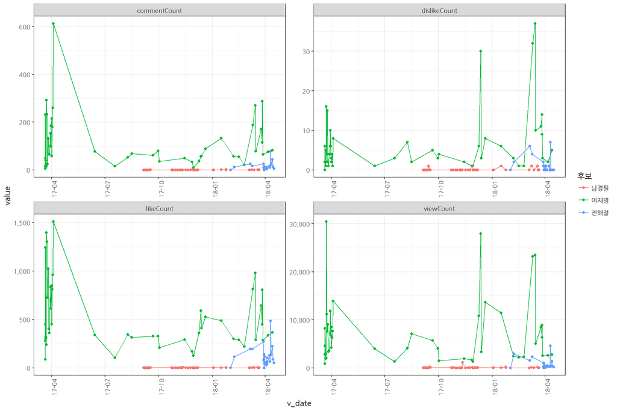

```r
## 2.2. 시각화 -----
## 2.1. 전체적인 흐름
gg_df %>%
  select(후보, v_date, contains("Count")) %>%
  gather(metric, value, -후보, -v_date) %>%
  mutate(v_date = ymd(v_date)) %>%
  filter(metric != "favoriteCount",
         v_date >= ymd("2017-01-01")) %>%
  ggplot(aes(x=v_date, y=value, group=후보, color=후보)) +
  geom_point() +
  geom_line() +
  facet_wrap(~ metric, scale="free", nrow = 3) +
  theme_bw(base_family="NanumGothic") +
  theme(axis.text.x = element_text(angle = 90, hjust = 1)) +
  scale_x_date(date_labels = "%y-%m") +
  scale_y_continuous(labels = scales::comma)
```

이번에는 2018년 이후만 살펴보자.

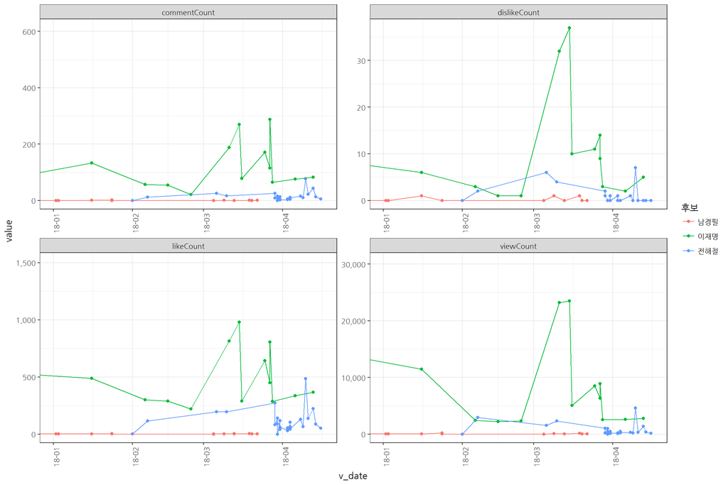

```r
## 2.2. 2018년 이후만...
gg_df %>%
  select(후보, v_date, contains("Count")) %>%
  gather(metric, value, -후보, -v_date) %>%
  mutate(v_date = ymd(v_date)) %>%
  filter(metric != "favoriteCount",
         v_date >= ymd("2017-01-01")) %>%
  ggplot(aes(x=v_date, y=value, group=후보, color=후보)) +
  geom_point() +
  geom_line() +
  facet_wrap(~ metric, scale="free", nrow = 3) +
  theme_bw(base_family="NanumGothic") +
  theme(axis.text.x = element_text(angle = 90, hjust = 1)) +
  scale_x_date(date_labels = "%y-%m") +
  scale_y_continuous(labels = scales::comma) +
  coord_cartesian(xlim=c(ymd("2018-01-01"), ymd("2018-04-17")))
```